# Sentiment Analysis of Psalms

AmandaRP

2019-05-18

I chose to work with the “Good New Translation” of the bible as it does not have copyright issues like some of the other translations (per the [American Bible Society](https://scripture.api.bible/)). We’ll use the tidytext and sentimentr R packages to do the analysis.

TODO:

- Add links to packages.
- Fix dynamic links near end.
- Spell check
- Comparison cloud of positive and negative words
- Add reference and link to tidytext book

Let’s start by reading data from biblegateway.com (using rvest) and doing a bit of cleaning:

```r
#Pull text and do a bit of cleaning:
get_chapter <- function(chapter){

  url <- str_c("https://www.biblegateway.com/passage/?search=Psalms+",
               chapter,
               "&version=GNT")

  html <- read_html(url)

  text <- html %>%
    html_node(".passage-wrap") %>%
    html_text() %>%
    str_extract("\\(GNT.{1,}") %>%
    str_replace("\\(GNT\\)","") %>%
    str_extract("\\d.{1,}") %>%
    str_replace_all("\\d{1,}", "") %>%
    str_replace_all("\\[\\w{1}\\]","")
}

#Use the function defined above to read all 150 chapters.
chapters <- map_chr(1:150, get_chapter) %>%
  tibble::enframe(name = "ch_num", value = "text")
```

Next, tokenize the text (each word will be a token), remove common English words such (e.g. “and” and “the”), and visualize using a wordcloud.

```r
#Tokenize and remove stopwords:
tidy_chapters <- chapters %>%
  unnest_tokens(word, text) %>%
  anti_join(stop_words)
```

```r
#wordcloud:
tidy_chapters %>%
  select(word) %>%
  group_by(word) %>%
  count() %>%
  wordcloud2()
```

[interactive chart not shown]

Note that I’ve changed all words capitalization to lowercase for the purposes of this analysis, which is the only reason that words such as “Lord” and “God” are not capitalized.

# Sentiment Analysis by Chapter

Next, we’ll use the tidytext package to join our data with a dictionary of sentiment words. tidytext comes with sentiment dictionaries, but I’m going to use the Jockers & Rinker sentiment dictionary from the lexicon package to better compare with a follow-on analysis using the sentimentr package. This dictionary contains positive and negative words and an associated sentiment score in the range [-1, 1]. A value of 1 is the most positive, 0 is neutral, and negative 1 is most negative.

There are a couple of ways to calculate the sentiment: either sum the sentiment scores for the words in each chapter (in which case chapter sentiment will be dependent on the length of the chapter), or take the average sentiment score over the words in each chapter (in which case chapter length will not affect the sentiment score). I think the choice depends on what makes the most sense for each application. You might be able to make the case that summing makes sense; a long and happy chapter may be considered more positive than a short and happy chapter. In anycase, I’m going to take the average to not bias the results by chapter length.

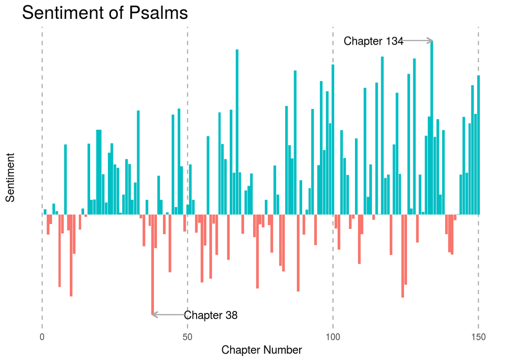

```r
psalms_sentiment_jockers_rinker <- tidy_chapters %>%
  inner_join(lexicon::hash_sentiment_jockers_rinker,
             by = c("word" = "x"),
             drop = FALSE) %>%
  group_by(ch_num) %>%
  summarize(avg_sentiment = mean(y))

#Find min and max sentiment chapters. Add annotation to graph.
max_sentiment <- psalms_sentiment_jockers_rinker %>%
  top_n(1, avg_sentiment)

min_sentiment <- psalms_sentiment_jockers_rinker %>%
  top_n(-1, avg_sentiment)

#Plot:
ggplot(psalms_sentiment_jockers_rinker,
       aes(ch_num, avg_sentiment,
           fill = avg_sentiment>0)) +
  geom_col(show.legend = FALSE) +
  labs(x = "Chapter Number",
       y = "Sentiment",
       title = "Sentiment of Psalms") +
  theme_minimal() +
  theme(axis.text.y = element_blank(),
        plot.background = element_blank(),
        panel.grid.minor.y = element_blank(),
        panel.grid.major.y = element_blank(),
        panel.grid.major.x = element_line(linetype = "dashed", color = "darkgrey"),
        panel.grid.minor.x = element_blank(),
        plot.title = element_text(size = 18)) +
  annotate("text",
           x = min_sentiment$ch_num + 20,
           y = min_sentiment$avg_sentiment,
           label = sprintf("Chapter %d", min_sentiment$ch_num)) +
  geom_curve(aes(x = min_sentiment$ch_num + 11,
                 y = min_sentiment$avg_sentiment,
                 xend = min_sentiment$ch_num,
                 yend = min_sentiment$avg_sentiment),
             curvature = 0,
             arrow = arrow(length=unit(2,"mm")),
             color = "darkgrey") +
  annotate("text",
           x = max_sentiment$ch_num - 20,
           y = max_sentiment$avg_sentiment,
           label = sprintf("Chapter %d", max_sentiment$ch_num)) +
  geom_curve(aes(x = max_sentiment$ch_num - 11,
                 y = max_sentiment$avg_sentiment,
                 xend = max_sentiment$ch_num,
                 yend = max_sentiment$avg_sentiment),
             curvature = 0,
             arrow = arrow(length=unit(2,"mm")),
             color = "darkgrey")
```

We see that [Chapter 134](https://www.biblegateway.com/passage/?search=Psalms+38&version=GNT) is the most positive and [Chapter 38](https://www.biblegateway.com/passage/?search=Psalms+134&version=GNT) is the most negative.

Next let’s take another look at the sentiment using the sentimentr package. It has some nice features such as valence shifters, which are described on the [package GitHub page](https://github.com/trinker/sentimentr) as follows:

> So what are these valence shifters? A negator flips the sign of a polarized word (e.g., “I do not like it.”). An amplifier (intensifier) increases the impact of a polarized word (e.g., “I really like it.”). A de-amplifier (downtoner) reduces the impact of a polarized word (e.g., “I hardly like it.”). An adversative conjunction overrules the previous clause containing a polarized word (e.g., “I like it but it’s not worth it.”).

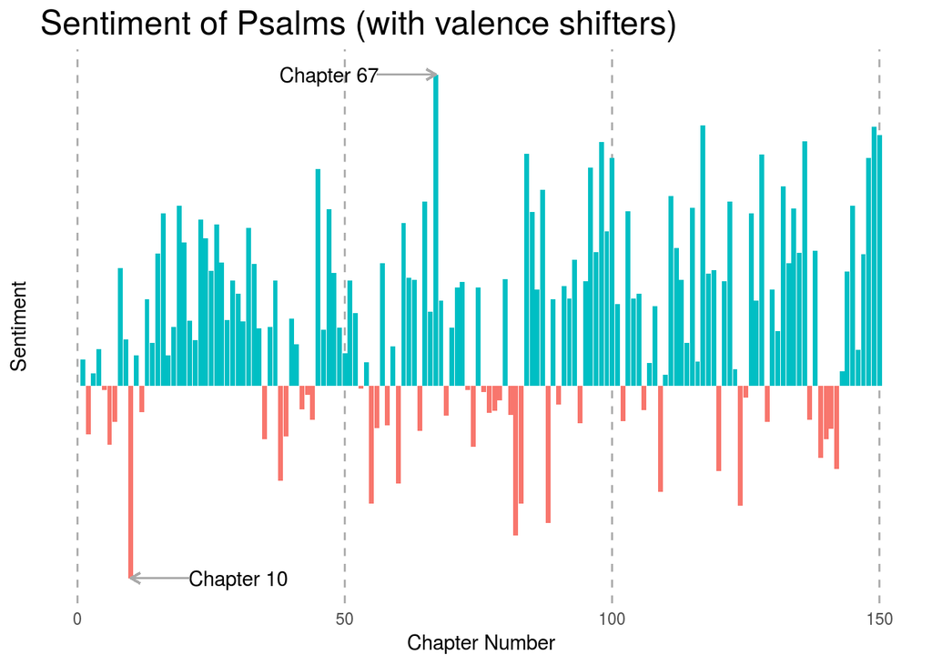

```r
psalms_sentiment_w_valence <- chapters %>%
    get_sentences() %$%
    sentiment_by(text, by = ch_num)

#Find min and max sentiment chapters. Add annotation to graph.
max_sentiment <- psalms_sentiment_w_valence %>%
  top_n(1, ave_sentiment)

min_sentiment <- psalms_sentiment_w_valence %>%
  top_n(-1, ave_sentiment)

#Plot:
ggplot(psalms_sentiment_w_valence, aes(ch_num, ave_sentiment, fill = ave_sentiment>0)) +
  geom_col(show.legend = FALSE) +
  labs(x = "Chapter Number",
       y = "Sentiment",
       title = "Sentiment of Psalms (with valence shifters)") +
  theme_minimal() +
  theme(axis.text.y = element_blank(),
        plot.background = element_blank(),
        panel.grid.minor.y = element_blank(),
        panel.grid.major.y = element_blank(),
        panel.grid.major.x = element_line(linetype = "dashed", color = "darkgrey"),
        panel.grid.minor.x = element_blank(),
        plot.title = element_text(size = 18)) +
  annotate("text",
           x = min_sentiment$ch_num + 20,
           y = min_sentiment$ave_sentiment,
           label = sprintf("Chapter %d", min_sentiment$ch_num)) +
  geom_curve(aes(x = min_sentiment$ch_num + 11,
                 y = min_sentiment$ave_sentiment,
                 xend = min_sentiment$ch_num,
                 yend = min_sentiment$ave_sentiment),
             curvature = 0,
             arrow = arrow(length=unit(2,"mm")),
             color = "darkgrey") +
  annotate("text",
           x = max_sentiment$ch_num - 20,
           y = max_sentiment$ave_sentiment,
           label = sprintf("Chapter %d", max_sentiment$ch_num)) +
  geom_curve(aes(x = max_sentiment$ch_num - 11,
                 y = max_sentiment$ave_sentiment,
                 xend = max_sentiment$ch_num,
                 yend = max_sentiment$ave_sentiment),
             curvature = 0,
             arrow = arrow(length=unit(2,"mm")),
             color = "darkgrey")
```

Now, after taking valence shifters into account, [Chapter 67](https://www.biblegateway.com/passage/?search=Psalms+67&version=GNT) is the most positive and [Chapter 10](https://www.biblegateway.com/passage/?search=Psalms+10&version=GNT) is the most negative. Additionally, between the two analyses, [Chapter 15](https://www.biblegateway.com/passage/?search=Psalms+15&version=GNT) switched from a slightly negative sentiment to a somewhat positive sentiment.

Have comments or feedback? Message me on Twitter: AmandaRPlunkett